# High-Dimensional Classification with PCA

Carolyne Chepkemboi

### Data Loading and Exploration

Load required libraries for this notebook.

```r
library(ggplot2)
library(dplyr)
# custom set select() (since MASS is loaded, overriding select())
select <- dplyr::select
library(FactoMineR)
library(factoextra)
library(class)
library(caret)
library(plotly)
library(knitr)
set.seed(6348)
```

Load the Human Activity Recognition Using Smartphones dataset [Human Activity Recognition Using Smartphones dataset](https://archive.ics.uci.edu/dataset/240/human+activity+recognition+using+smartphones) into memory.

The inner UCI HAR Dataset folder, as downloaded from the UC Irvine repository and unzipped, should be placed in the same directory as this file.

Alternative solution: unzip the data, drag the “UCI HAR Dataset” subfolder into documents, set wd as setwd(“~/Documents”), and the code should compile.

```r
# Training data/labels
X_train_raw <- read.table("C:/Users/carolynechep/Desktop/human+activity+recognition+using+smartphones/UCI HAR Dataset/UCI HAR Dataset/train/X_train.txt")
y_train_raw <- read.table("C:/Users/carolynechep/Desktop/human+activity+recognition+using+smartphones/UCI HAR Dataset/UCI HAR Dataset/train/y_train.txt")

# Test data/labels
X_test_raw <- read.table("C:/Users/carolynechep/Desktop/human+activity+recognition+using+smartphones/UCI HAR Dataset/UCI HAR Dataset/test/X_test.txt")
y_test_raw <- read.table("C:/Users/carolynechep/Desktop/human+activity+recognition+using+smartphones/UCI HAR Dataset/UCI HAR Dataset/test/y_test.txt")
```

```r
dim(X_train_raw) %>% print
```

```
## [1] 7352  561
```

```r
dim(X_test_raw) %>% print
```

```
## [1] 2947  561
```

```r
features <- dim(X_train_raw)[2]
train_len <- dim(X_train_raw)[1]
test_len <- dim(X_test_raw)[1]

X_train_raw[1:5,1:3] %>% print
```

```
##          V1          V2         V3
## 1 0.2885845 -0.02029417 -0.1329051
## 2 0.2784188 -0.01641057 -0.1235202
## 3 0.2796531 -0.01946716 -0.1134617
## 4 0.2791739 -0.02620065 -0.1232826
## 5 0.2766288 -0.01656965 -0.1153619
```

```r
y_train_raw[1:30,] %>% print
```

```
##  [1] 5 5 5 5 5 5 5 5 5 5 5 5 5 5 5 5 5 5 5 5 5 5 5 5 5 5 5 4 4 4
```

Rename the columns of the features dataframes to the given description of the corresponding feature.

```r
feature_descs <- read.table("C:/Users/carolynechep/Desktop/human+activity+recognition+using+smartphones/UCI HAR Dataset/UCI HAR Dataset/features.txt")
colnames(feature_descs) <- c("index", "desc")
colnames(X_train_raw) <- feature_descs$desc
colnames(X_test_raw) <- feature_descs$desc

generic_colnames <- paste("V", sapply(1:features, toString), sep = "")
```

```r
X_train_raw[1:5,1:3] %>% print
```

```
##   tBodyAcc-mean()-X tBodyAcc-mean()-Y tBodyAcc-mean()-Z
## 1         0.2885845       -0.02029417        -0.1329051
## 2         0.2784188       -0.01641057        -0.1235202
## 3         0.2796531       -0.01946716        -0.1134617
## 4         0.2791739       -0.02620065        -0.1232826
## 5         0.2766288       -0.01656965        -0.1153619
```

Add a column to the labels dataframes with the corresponding activity name for ease of interpretability.

```r
classes <- read.table("C:/Users/carolynechep/Desktop/human+activity+recognition+using+smartphones/UCI HAR Dataset/UCI HAR Dataset/activity_labels.txt")

y_train <- y_train_raw %>%
  mutate(index = V1,
    activity = classes$V2[index]) %>%
  select(index, activity)

y_test <- y_test_raw %>%
  mutate(index = V1,
    activity = classes$V2[index]) %>%
  select(index, activity)
```

```r
y_train %>% count(activity) %>% print
```

```
##             activity    n
## 1             LAYING 1407
## 2            SITTING 1286
## 3           STANDING 1374
## 4            WALKING 1226
## 5 WALKING_DOWNSTAIRS  986
## 6   WALKING_UPSTAIRS 1073
```

Scale and center the raw features. We can’t use `scale()` since we need to scale the test data with respect to the means and standard deviations of the training data.

```r
# Calculate the mean and sd of each raw feature
X_train_raw_mean <- colMeans(X_train_raw)
X_train_raw_sd <- apply(X_train_raw, 2, sd)

# Subtract the mean from each feature, then divide by the sd
X_train <- X_train_raw %>%
  sweep(2, X_train_raw_mean, "-") %>%
  sweep(2, X_train_raw_sd, "/")

X_test <- X_test_raw %>%
  sweep(2, X_train_raw_mean, "-") %>%
  sweep(2, X_train_raw_sd, "/")
```

```r
X_train[1:5,1:3] %>% print
```

```
##   tBodyAcc-mean()-X tBodyAcc-mean()-Y tBodyAcc-mean()-Z
## 1        0.20062792       -0.06367827       -0.41959991
## 2        0.05594407        0.03148353       -0.25389109
## 3        0.07351035       -0.04341352       -0.07628949
## 4        0.06669123       -0.20840748       -0.24969547
## 5        0.03046690        0.02758534       -0.10984037
```

### Exploratory Data Analysis

### Activity Class Distribution

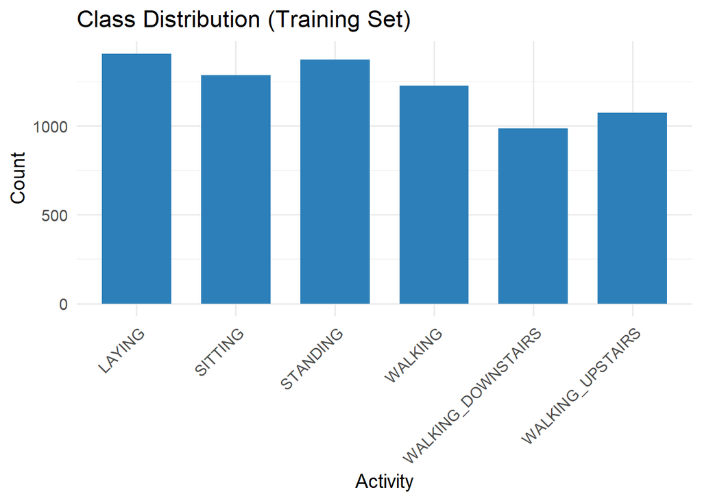

```r
library(ggplot2)

y_train %>%
  count(activity) %>%
  ggplot(aes(x = activity, y = n)) +
  geom_bar(stat = "identity", fill = "#2C7FB8", width = 0.7) +
  theme_minimal(base_size = 14) +
  labs(title = "Class Distribution (Training Set)",
       x = "Activity", y = "Count") +
  theme(axis.text.x = element_text(angle = 45, hjust = 1))
```

### Feature Density Distributions

```r
library(tidyr)
```

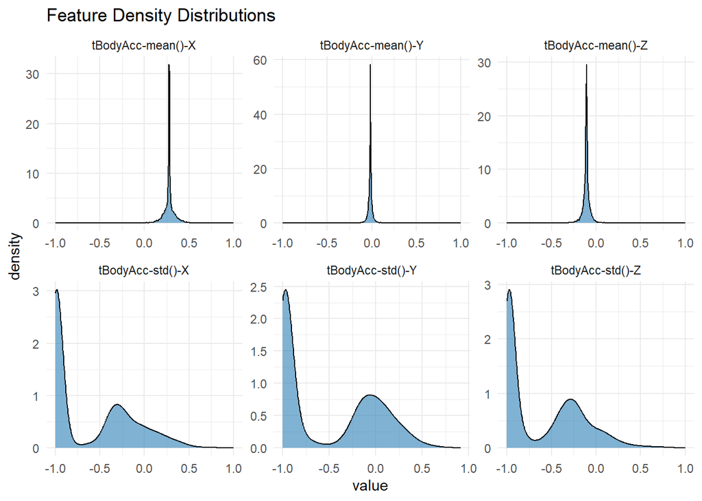

```r
X_sample <- X_train_raw[, 1:6]

X_long <- X_sample %>%
  as.data.frame() %>%
  pivot_longer(cols = everything())

ggplot(X_long, aes(x = value)) +
  geom_density(fill = "#2C7FB8", alpha = 0.6) +
  facet_wrap(~name, scales = "free") +
  theme_minimal() +
  labs(title = "Feature Density Distributions")
```

### Correlation Heatmap

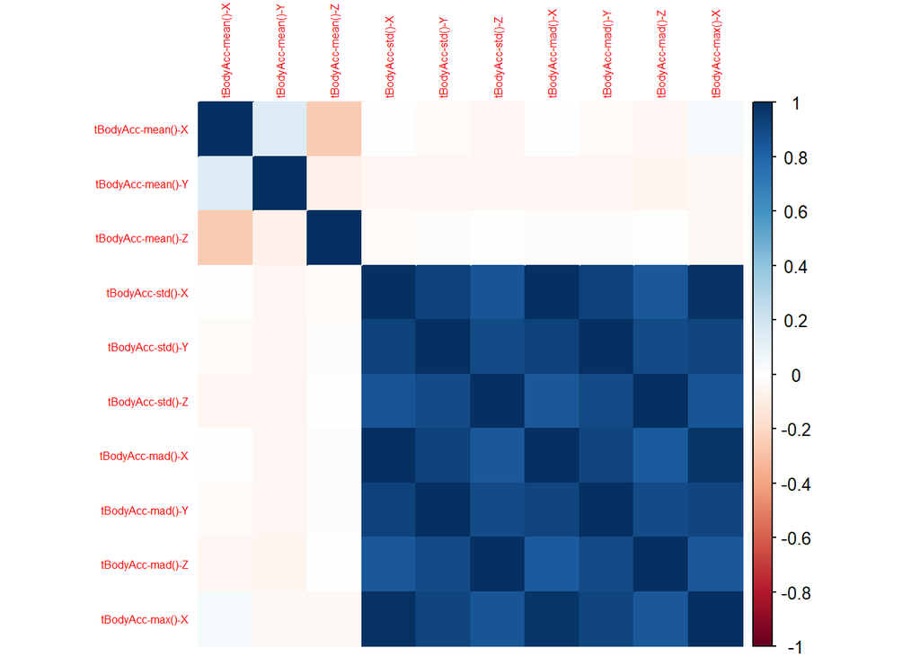

```r
library(corrplot)
cor_mat <- cor(X_train_raw[, 1:10])  # subset for readability

corrplot(cor_mat, method = "color", tl.cex = 0.5)
```

### Standardization Scale and center the raw features of training data using sweep()

```r
# Calculate the mean and sd of each raw feature
X_train_raw_mean <- colMeans(X_train_raw)
X_train_raw_sd <- apply(X_train_raw, 2, sd)

# Subtract the mean from each feature, then divide by the sd
X_train <- X_train_raw %>%
  sweep(2, X_train_raw_mean, "-") %>%
  sweep(2, X_train_raw_sd, "/")

X_test <- X_test_raw %>%
  sweep(2, X_train_raw_mean, "-") %>%
  sweep(2, X_train_raw_sd, "/")
```

```r
X_train[1:5,1:3] %>% print
```

```
##   tBodyAcc-mean()-X tBodyAcc-mean()-Y tBodyAcc-mean()-Z
## 1        0.20062792       -0.06367827       -0.41959991
## 2        0.05594407        0.03148353       -0.25389109
## 3        0.07351035       -0.04341352       -0.07628949
## 4        0.06669123       -0.20840748       -0.24969547
## 5        0.03046690        0.02758534       -0.10984037
```

### Additional EDA

Check if the data has missing values to handle

```r
sum(is.na(X_train_raw))
```

```
## [1] 0
```

```r
sum(is.na(X_test_raw))
```

```
## [1] 0
```

Summary statistics and histogram of standard deviations to corroborate scaling

```r
standard_deviations <- apply(X_train_raw, 2, sd)
summary(standard_deviations)
```

```
##    Min. 1st Qu.  Median    Mean 3rd Qu.    Max.
## 0.04081 0.19158 0.26543 0.28369 0.36245 0.75173
```

```r
IQR(standard_deviations)
```

```
## [1] 0.1708739
```

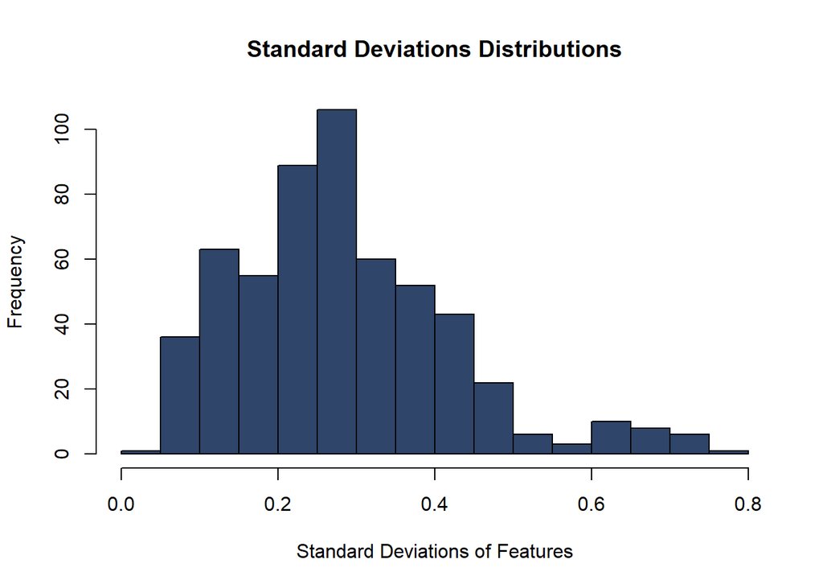

```r
hist(standard_deviations,
     main = "Standard Deviations Distributions",
     xlab = "Standard Deviations of Features",
     col = "#2f4569")
```

Number and percentage of absolute and raw correlations greater than 0.9.

```r
correlations <- cor(X_train_raw)[upper.tri(cor(X_train_raw))]
sum(abs(correlations) > 0.9)
```

```
## [1] 8206
```

```r
sum(correlations > 0.9)
```

```
## [1] 7702
```

```r
sum(abs(correlations) > 0.9) / ((features * (features-1)) / 2)
```

```
## [1] 0.0522409
```

```r
sum(correlations > 0.9) / ((features * (features-1)) / 2)
```

```
## [1] 0.04903234
```

Percentage of absolute and raw correlations greater than 0.8.

```r
sum(abs(correlations) > 0.8) / ((features * (features-1)) / 2)
```

```
## [1] 0.1467914
```

```r
sum(correlations > 0.8) / ((features * (features-1)) / 2)
```

```
## [1] 0.1329641
```

Distribution of pairwise correlations.

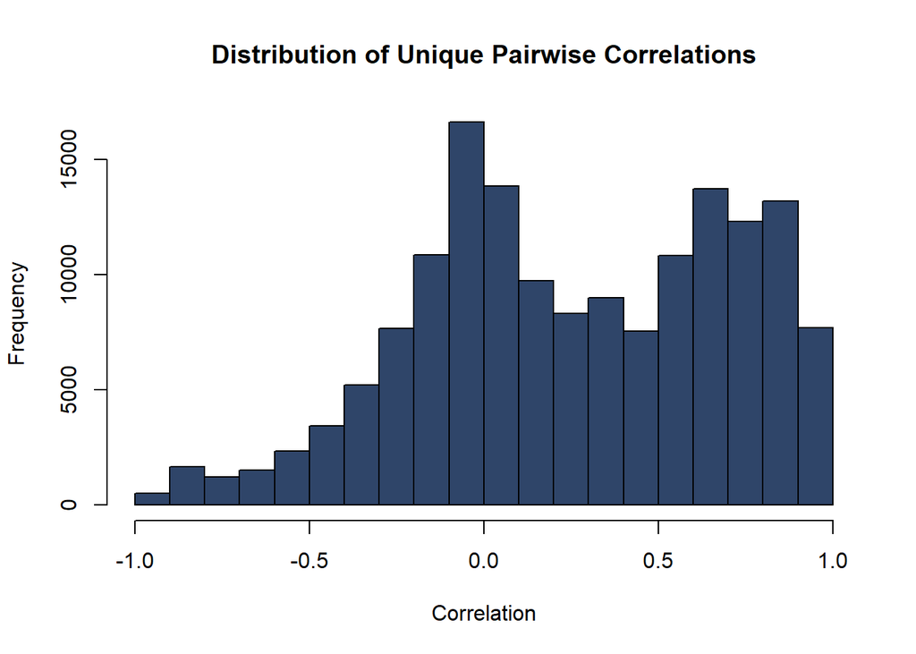

```r
hist(correlations,
     main = "Distribution of Unique Pairwise Correlations",
     xlab = "Correlation",
     col = "#2f4569")
```

### LDA Baseline Model

```r
library(MASS)
library(caret)

# Make sure activity labels are factors
y_train$activity <- factor(y_train$activity)
y_test$activity <- factor(y_test$activity, levels = levels(y_train$activity))

# Start time to measure efficiency
baseline_start <- Sys.time()

# Train baseline LDA model
baseline_model <- lda(x = X_train, grouping = y_train$activity)
# Predict test labels
baseline_pred <- predict(baseline_model, X_test)$class

# End time
baseline_end <- Sys.time()

# Force predictions to have same factor levels as y_test
baseline_pred <- factor(baseline_pred, levels = levels(y_test$activity))

# Confusion matrix
baseline_cm <- confusionMatrix(data = baseline_pred,
                               reference = y_test$activity)

# baseline training accuracy (to assess theoretical upper limit of test accuracy)
baseline_train_pred <- predict(baseline_model, X_train)$class

baseline_train_pred <- factor(baseline_train_pred,
                              levels = levels(y_train$activity))

baseline_train_cm <- confusionMatrix(data = baseline_train_pred,
                                     reference = y_train$activity)

baseline_train_cm$overall["Accuracy"]
```

```
##  Accuracy
## 0.9857182
```

### Visualization of the confusion matrix

```r
cm <- confusionMatrix(baseline_pred, y_test$activity)
cm$table
```

```
##                     Reference
## Prediction           LAYING SITTING STANDING WALKING WALKING_DOWNSTAIRS
##   LAYING                537       0        0       0                  0
##   SITTING                 0     434       22       0                  0
##   STANDING                0      56      510       0                  0
##   WALKING                 0       0        0     490                  1
##   WALKING_DOWNSTAIRS      0       0        0       0                405
##   WALKING_UPSTAIRS        0       1        0       6                 14
##                     Reference
## Prediction           WALKING_UPSTAIRS
##   LAYING                            0
##   SITTING                           0
##   STANDING                          0
##   WALKING                          11
##   WALKING_DOWNSTAIRS                0
##   WALKING_UPSTAIRS                460
```

```r
accuracy <- cm$overall["Accuracy"]
print(accuracy)
```

```
##  Accuracy
## 0.9623346
```

```r
metrics <- cm$byClass[, c("Precision", "Recall", "F1")]
metrics
```

```
##                           Precision    Recall        F1
## Class: LAYING             1.0000000 1.0000000 1.0000000
## Class: SITTING            0.9517544 0.8839104 0.9165787
## Class: STANDING           0.9010601 0.9586466 0.9289617
## Class: WALKING            0.9760956 0.9879032 0.9819639
## Class: WALKING_DOWNSTAIRS 1.0000000 0.9642857 0.9818182
## Class: WALKING_UPSTAIRS   0.9563410 0.9766454 0.9663866
```

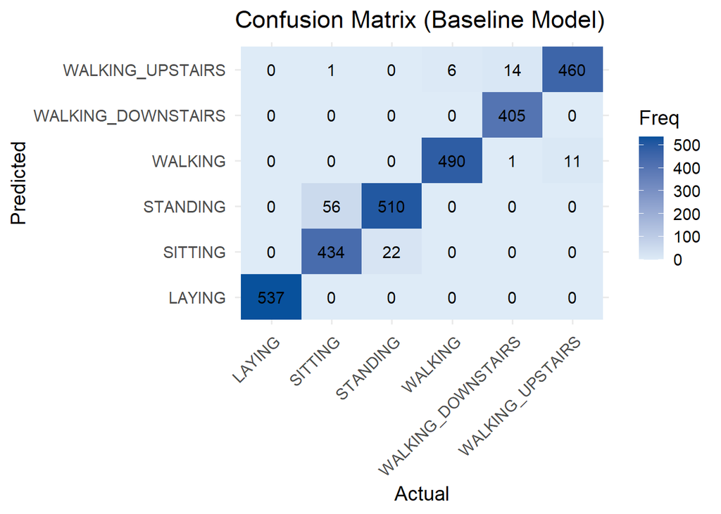

```r
cm_df <- as.data.frame(cm$table)
colnames(cm_df) <- c("Predicted", "Actual", "Freq")

library(ggplot2)

ggplot(cm_df, aes(x = Actual, y = Predicted, fill = Freq)) +
  geom_tile() +
  geom_text(aes(label = Freq), color = "black", size = 4) +
  scale_fill_gradient(low = "#deebf7", high = "#08519c") +
  theme_minimal(base_size = 14) +
  labs(
    title = "Confusion Matrix (Baseline Model)",
    x = "Actual",
    y = "Predicted"
  ) +
  theme(axis.text.x = element_text(angle = 45, hjust = 1))
```

### Principal Component Analysis

There are multiple ways to perform PCA in R; which one is the fastest?

Calculate the sample covariance matrix of `X_train`, then find the eigenvalues and corresponding eigenvectors and multiply `X_train` by the latter.

```r
scov.start <- Sys.time()
X_train.scov <- t(X_train) %*% as.matrix(X_train) / (nrow(X_train)-1)
X_train.scov.eigen <- X_train.scov %>% eigen
X_train.scov.pcs <- as.matrix(X_train) %*% X_train.scov.eigen$vectors
scov.end <- Sys.time()
X_train.scov.eivals <- X_train.scov.eigen$values
```

```r
(scov.end - scov.start) %>% print
```

```
## Time difference of 6.651428 secs
```

Calculate the singular value decomposition $UDV^T$ of `X_train`, and derive the principal components $YV=UD$.

```r
svd.start <- Sys.time()
X_train.svd <- X_train %>% svd
X_train.svd.pcs <- X_train.svd$u %*% diag(X_train.svd$d)
X_train.svd.eivals <- X_train.svd$d^2 / (nrow(X_train)-1)
svd.end <- Sys.time()
```

```r
(svd.end - svd.start) %>% print
```

```
## Time difference of 17.278 secs
```

Use the `PCA()` function from `FactoMineR` (We will proceed using this, even though it is slower, because the results are more conducive to statistical analysis)

```r
pca.start <- Sys.time()
X_train.pca <- PCA(X_train, ncp = nrow(X_train), graph = FALSE)
pca.end <- Sys.time()
X_train.pcs <- X_train.pca[["ind"]][["coord"]] %>% as.data.frame
colnames(X_train.pcs) <- generic_colnames
X_train.eivals <- X_train.pca$eig[,1]

X_train.v <- X_train.pca$svd$V %>% as.data.frame
X_test.pcs <- (as.matrix(X_test) %*% as.matrix(X_train.v)) %>% as.data.frame
colnames(X_test.pcs) <- generic_colnames
```

```r
(pca.end - pca.start) %>% print
```

```
## Time difference of 18.38748 secs
```

```r
X_train.pcs[1:5,1:3] %>% print
```

```
##          V1       V2         V3
## 1 -16.13854 2.152024  3.1447802
## 2 -15.29619 1.387144 -0.6822211
## 3 -15.13702 2.473351 -1.7566406
## 4 -15.35088 3.915681 -1.7903224
## 5 -15.54481 4.598737 -2.1885821
```

```r
X_train.eivals[1:5] %>% print
```

```
##    comp 1    comp 2    comp 3    comp 4    comp 5
## 284.88238  36.91762  15.74411  14.04717  10.59328
```

Create a scatter plot of the first two principal components of the data…

```r
scatter2 <- plot_ly(x=X_train.pcs[,1], y=X_train.pcs[,2],
        type="scatter", mode="markers", color=y_train$activity) %>%
  layout(title = 'First Two Principal Components')

scatter2
```

[interactive chart not shown]

and of the first three principal components.

```r
scatter3 <- plot_ly(x=X_train.pcs[[1]], y=X_train.pcs[[2]],
                    z=X_train.pcs[[3]],
        type="scatter3d", mode="markers", color=y_train$activity)  %>%
  layout(title = 'First Three Principal Components')

scatter3
```

[interactive chart not shown]

How many principal components should we use in building models? Generate a scree plot of cumulative variance.

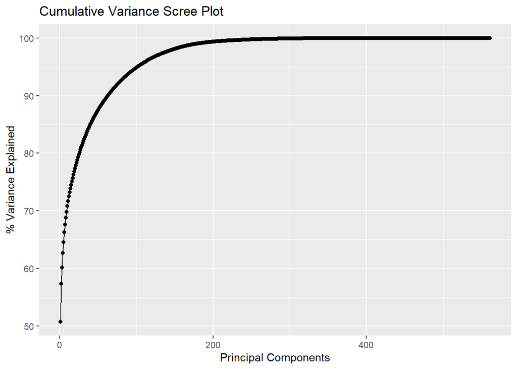

```r
X_train.cum_var <- X_train.pca$eig[,3]

scree <- ggplot() +
  geom_line(aes(x=1:length(X_train.cum_var), y=X_train.cum_var)) +
  geom_point(aes(x=1:length(X_train.cum_var), y=X_train.cum_var)) +
  labs(title="Cumulative Variance Scree Plot", x="Principal Components",
       y="% Variance Explained")

scree %>% plot
```

How many principal components do we need reach certain thresholds of variance?

```r
# 80%
which(X_train.cum_var < 80) %>% length %>% +1 %>% print
```

```
## [1] 26
```

```r
# 90%
which(X_train.cum_var < 90) %>% length %>% +1 %>% print
```

```
## [1] 63
```

```r
# 95%
which(X_train.cum_var < 95) %>% length %>% +1 %>% print
```

```
## [1] 102
```

```r
# 99%
which(X_train.cum_var < 99) %>% length %>% +1 %>% print
```

```
## [1] 179
```

```r
# 99.9%
which(X_train.cum_var < 99.9) %>% length %>% +1 %>% print
```

```
## [1] 296
```

What threshold of variance do certain numbers of principal compoments reach?

```r
# 1
X_train.cum_var[1] %>% print
```

```
##   comp 1
## 50.78117
```

```r
# 5
X_train.cum_var[5] %>% print
```

```
##   comp 5
## 64.56053
```

```r
# 10
X_train.cum_var[10] %>% print
```

```
##  comp 10
## 70.81557
```

```r
# 20
X_train.cum_var[20] %>% print
```

```
##  comp 20
## 77.37465
```

```r
# 50
X_train.cum_var[50] %>% print
```

```
##  comp 50
## 87.51836
```

```r
# 100
X_train.cum_var[100] %>% print
```

```
## comp 100
##  94.8915
```

```r
# 200
X_train.cum_var[200] %>% print
```

```
## comp 200
## 99.36361
```

Which variables contribute most to the first principal component?

```r
X_train.pc1_cont <- X_train.v[,1] %>% sort(index.return=TRUE, decreasing=TRUE)

t5_ind <- 1:5

X_train.pc1_cont_t5 <- X_train.pc1_cont$ix[t5_ind]

X_train.pc1_cont_t5 %>% print
```

```
## [1] 281 360  96 439 227
```

```r
feature_descs$desc[X_train.pc1_cont_t5] %>% print
```

```
## [1] "fBodyAcc-sma()"         "fBodyAccJerk-sma()"     "tBodyAccJerk-sma()"
## [4] "fBodyGyro-sma()"        "tBodyAccJerkMag-mean()"
```

```r
X_train.v[X_train.pc1_cont_t5,1] %>% print
```

```
## [1] 0.05857110 0.05856808 0.05853759 0.05853133 0.05849275
```

Which variables contribute least to the first principal component?

```r
b5_ind <- (features-4):features
X_train.pc1_cont_b5 <- X_train.pc1_cont$ix[b5_ind]

X_train.pc1_cont_b5 %>% print
```

```
## [1] 95 94 93 14 13
```

```r
feature_descs$desc[X_train.pc1_cont_b5] %>% print
```

```
## [1] "tBodyAccJerk-min()-Z" "tBodyAccJerk-min()-Y" "tBodyAccJerk-min()-X"
## [4] "tBodyAcc-min()-Y"     "tBodyAcc-min()-X"
```

```r
X_train.pc1_cont$x[b5_ind] %>% print
```

```
## [1] -0.05449351 -0.05485134 -0.05558397 -0.05575286 -0.05629009
```

Plot the coefficients of each variable in the first principle component in decreasing order.

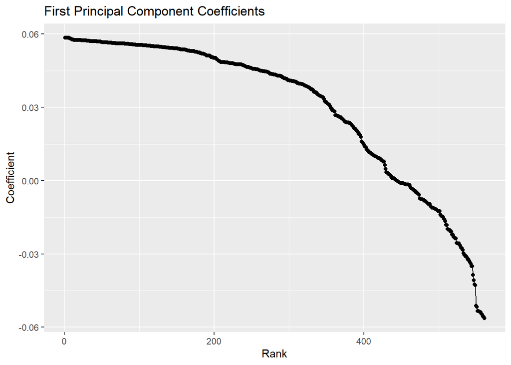

```r
pc1_plot <- ggplot() +
  geom_line(aes(x=1:length(X_train.pc1_cont$x), y=X_train.pc1_cont$x)) +
  geom_point(aes(x=1:length(X_train.pc1_cont$x), y=X_train.pc1_cont$x)) +
  labs(title="First Principal Component Coefficients", x="Rank",
       y="Coefficient")

pc1_plot %>% plot
```

### PCA components for transformation

We chose the first PCs explaining at least 95% of variance of the original features.

```r
pcs_95 <- which(X_train.cum_var >= 95)[1]
pcs_95
```

```
## comp 102
##      102
```

Using these, subset the training and test sets using these first PCs (note: no leakage, only training set used to compute loadings).

```r
X_train.pcs_95 <- X_train.pcs[, 1:pcs_95]
X_test.pcs_95 <- X_test.pcs[, 1:pcs_95]
```

### LDA on PCA transformed features

After transforming the features using PCA, we fit another LDA model.

We compare all metrics including precision, recall, f1, accuracy, and runtime against the original model.

Note To Professor: The “nicer tables” included in the presentation will only load if you use library(“gt”). The package will not install automatically when knitting, so the code will be left but commented out. The knitr tables should produce the same results as our presentation (minus runtime differences by hardware).

```r
# load needed libraries
library(MASS)
library(caret)

# refactoring due to errors encountered
activity_levels <- c("LAYING", "SITTING", "STANDING", "WALKING",
                     "WALKING_DOWNSTAIRS", "WALKING_UPSTAIRS")
y_train$activity <- factor(as.character(y_train$activity),
                           levels = activity_levels)
y_test$activity <- factor(as.character(y_test$activity),
                           levels = activity_levels)

# computational efficiency start
eff_start <- Sys.time()

# training the model on the transformed dataset on 102 components
pca_lda <- lda(x = X_train.pcs_95, grouping = y_train$activity)

# create predictions
pca_lda_pred <- predict(pca_lda, X_test.pcs_95)$class

# computational efficiency end
eff_end <- Sys.time()

# create predictions on transformed test set
pca_lda_pred <- factor(as.character(pca_lda_pred),
                       levels = activity_levels)

# confusion matrix
cm_pca_lda <- confusionMatrix(pca_lda_pred,
                              reference = y_test$activity)
cm_pca_lda
```

```
## Confusion Matrix and Statistics
##
##                     Reference
## Prediction           LAYING SITTING STANDING WALKING WALKING_DOWNSTAIRS
##   LAYING                537       0        0       0                  0
##   SITTING                 0     420       45       0                  0
##   STANDING                0      70      487       0                  0
##   WALKING                 0       0        0     491                 15
##   WALKING_DOWNSTAIRS      0       0        0       5                366
##   WALKING_UPSTAIRS        0       1        0       0                 39
##                     Reference
## Prediction           WALKING_UPSTAIRS
##   LAYING                            0
##   SITTING                           0
##   STANDING                          0
##   WALKING                          28
##   WALKING_DOWNSTAIRS                5
##   WALKING_UPSTAIRS                438
##
## Overall Statistics
##
##                Accuracy : 0.9294
##                  95% CI : (0.9196, 0.9384)
##     No Information Rate : 0.1822
##     P-Value [Acc > NIR] : < 2.2e-16
##
##                   Kappa : 0.9151
##
##  Mcnemar's Test P-Value : NA
##
## Statistics by Class:
##
##                      Class: LAYING Class: SITTING Class: STANDING
## Sensitivity                 1.0000         0.8554          0.9154
## Specificity                 1.0000         0.9817          0.9710
## Pos Pred Value              1.0000         0.9032          0.8743
## Neg Pred Value              1.0000         0.9714          0.9812
## Prevalence                  0.1822         0.1666          0.1805
## Detection Rate              0.1822         0.1425          0.1653
## Detection Prevalence        0.1822         0.1578          0.1890
## Balanced Accuracy           1.0000         0.9185          0.9432
##                      Class: WALKING Class: WALKING_DOWNSTAIRS
## Sensitivity                  0.9899                    0.8714
## Specificity                  0.9825                    0.9960
## Pos Pred Value               0.9195                    0.9734
## Neg Pred Value               0.9979                    0.9790
## Prevalence                   0.1683                    0.1425
## Detection Rate               0.1666                    0.1242
## Detection Prevalence         0.1812                    0.1276
## Balanced Accuracy            0.9862                    0.9337
##                      Class: WALKING_UPSTAIRS
## Sensitivity                           0.9299
## Specificity                           0.9838
## Pos Pred Value                        0.9163
## Neg Pred Value                        0.9866
## Prevalence                            0.1598
## Detection Rate                        0.1486
## Detection Prevalence                  0.1622
## Balanced Accuracy                     0.9569
```

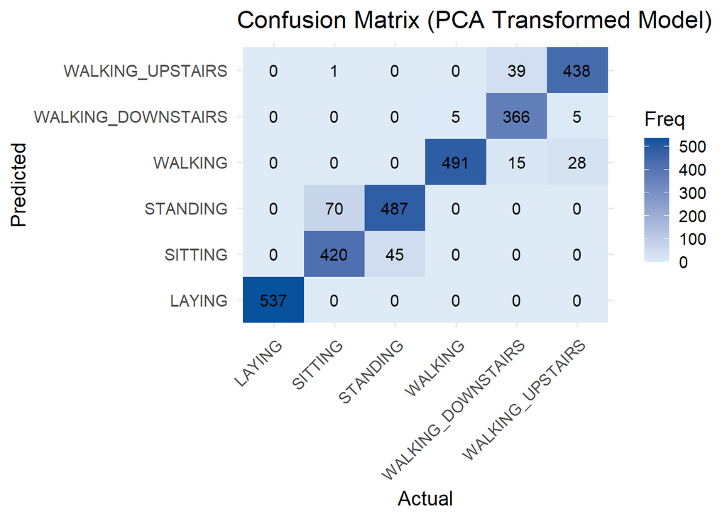

```r
# convert into a dataframe for viewing
cm_pca_lda_df <- as.data.frame(cm_pca_lda$table)
colnames(cm_pca_lda_df) <- c("Predicted", "Actual", "Freq")

# visualize confusion matrix, setup from earlier copied exactly
ggplot(cm_pca_lda_df, aes(x = Actual, y = Predicted, fill = Freq)) +
  geom_tile() +
  geom_text(aes(label = Freq), color = "black", size = 4) +
  scale_fill_gradient(low = "#deebf7", high = "#08519c") +
  theme_minimal(base_size = 14) +
  labs(
    title = "Confusion Matrix (PCA Transformed Model)",
    x = "Actual",
    y = "Predicted"
  ) +
  theme(axis.text.x = element_text(angle = 45, hjust = 1))
```

```r
# percent of original features
print(pcs_95 / ncol(X_train_raw) * 100)
```

```
## comp 102
## 18.18182
```

```r
# Find the metrics
print(cm_pca_lda$overall["Accuracy"])
```

```
##  Accuracy
## 0.9294197
```

```r
print(cm_pca_lda$byClass[, c("Precision", "Recall", "F1")])
```

```
##                           Precision    Recall        F1
## Class: LAYING             1.0000000 1.0000000 1.0000000
## Class: SITTING            0.9032258 0.8553971 0.8786611
## Class: STANDING           0.8743268 0.9154135 0.8943985
## Class: WALKING            0.9194757 0.9899194 0.9533981
## Class: WALKING_DOWNSTAIRS 0.9734043 0.8714286 0.9195980
## Class: WALKING_UPSTAIRS   0.9163180 0.9299363 0.9230769
```

```r
# save for viewing
accuracy2 <- cm_pca_lda$overall["Accuracy"]
metrics2 <- cm_pca_lda$byClass[, c("Precision", "Recall", "F1")]

# After PCA time
time2 <- eff_end - eff_start
print(time2)
```

```
## Time difference of 1.05162 secs
```

```r
# before PCA time
time1 <- baseline_end - baseline_start
print(time1)
```

```
## Time difference of 17.31463 secs
```

```r
# convert into a usable format for calculation
time1 <- as.numeric(time1, unit = "secs")
time2 <- as.numeric(time2, unit = "secs")

# relative speedup
print((time1-time2) / time1 * 100)
```

```
## [1] 93.92641
```

```r
# print accuracy before and after
print(accuracy)
```

```
##  Accuracy
## 0.9623346
```

```r
print(accuracy2)
```

```
##  Accuracy
## 0.9294197
```

```r
# assemble before and after in a dataframe
baseline_metrics <- data.frame(
  Precision = round(metrics[, "Precision"], 3),
  Recall = round(metrics[, "Recall"], 3),
  F1 = round(metrics[, "F1"], 3),
  Runtime = round(time1, 3)
)

after_metrics <- data.frame(
  Precision = round(metrics2[, "Precision"], 3),
  Recall = round(metrics2[, "Recall"], 3),
  F1 = round(metrics2[, "F1"], 3),
  Runtime = round(time2, 3)
)

# knitr
library(knitr)

# gt
# library("gt")

# print with knitr
knitr::kable(baseline_metrics, caption = "LDA metrics before PCA")
```

LDA metrics before PCA

|  | Precision | Recall | F1 | Runtime |
| --- | --- | --- | --- | --- |
| Class: LAYING | 1.000 | 1.000 | 1.000 | 17.315 |
| Class: SITTING | 0.952 | 0.884 | 0.917 | 17.315 |
| Class: STANDING | 0.901 | 0.959 | 0.929 | 17.315 |
| Class: WALKING | 0.976 | 0.988 | 0.982 | 17.315 |
| Class: WALKING_DOWNSTAIRS | 1.000 | 0.964 | 0.982 | 17.315 |
| Class: WALKING_UPSTAIRS | 0.956 | 0.977 | 0.966 | 17.315 |

```r
# nicer table
baseline_metrics$Class <- rownames(baseline_metrics)
baseline_metrics$Class <- gsub("Class: ", "", baseline_metrics$Class)
baseline_metrics <- baseline_metrics[, c("Class", "Precision", "Recall", "F1", "Runtime")]

#baseline_metrics %>%
#  gt()

knitr::kable(after_metrics, caption = "LDA metrics after PCA")
```

LDA metrics after PCA

|  | Precision | Recall | F1 | Runtime |
| --- | --- | --- | --- | --- |
| Class: LAYING | 1.000 | 1.000 | 1.000 | 1.052 |
| Class: SITTING | 0.903 | 0.855 | 0.879 | 1.052 |
| Class: STANDING | 0.874 | 0.915 | 0.894 | 1.052 |
| Class: WALKING | 0.919 | 0.990 | 0.953 | 1.052 |
| Class: WALKING_DOWNSTAIRS | 0.973 | 0.871 | 0.920 | 1.052 |
| Class: WALKING_UPSTAIRS | 0.916 | 0.930 | 0.923 | 1.052 |

```r
# nicer table
after_metrics$Class <- rownames(after_metrics)
after_metrics$Class <- gsub("Class: ", "", after_metrics$Class)
after_metrics <- after_metrics[, c("Class", "Precision", "Recall", "F1", "Runtime")]

#after_metrics %>%
#  gt()

print(baseline_metrics)
```

```
##                                        Class Precision Recall    F1 Runtime
## Class: LAYING                         LAYING     1.000  1.000 1.000  17.315
## Class: SITTING                       SITTING     0.952  0.884 0.917  17.315
## Class: STANDING                     STANDING     0.901  0.959 0.929  17.315
## Class: WALKING                       WALKING     0.976  0.988 0.982  17.315
## Class: WALKING_DOWNSTAIRS WALKING_DOWNSTAIRS     1.000  0.964 0.982  17.315
## Class: WALKING_UPSTAIRS     WALKING_UPSTAIRS     0.956  0.977 0.966  17.315
```

```r
# F1 comparison
round(metrics2[, "F1"] - metrics[, "F1"], 3)
```

```
##             Class: LAYING            Class: SITTING           Class: STANDING
##                     0.000                    -0.038                    -0.035
##            Class: WALKING Class: WALKING_DOWNSTAIRS   Class: WALKING_UPSTAIRS
##                    -0.029                    -0.062                    -0.043
```

```r
print(summary(round(metrics2[, "F1"] - metrics[, "F1"], 3)))
```

```
##     Min.  1st Qu.   Median     Mean  3rd Qu.     Max.
## -0.06200 -0.04175 -0.03650 -0.03450 -0.03050  0.00000
```

```r
# Model comparison dataframe
model_comparison <- data.frame(
  Metric = c("Features", "Accuracy", "Mean F1", "Runtime (sec)"),
  Baseline = c(as.character(ncol(X_train_raw)),
       round(as.numeric(accuracy), 3),
       round(mean(metrics[, "F1"]), 3),
       round(time1, 3)),
  PCA = c(as.character(ncol(X_train.pcs_95)),
       round(as.numeric(accuracy2), 3),
       round(mean(metrics2[, "F1"]), 3),
       round(time2, 3)),
  Change = c(
       paste0(round((ncol(X_train.pcs_95) - ncol(X_train_raw)) / ncol(X_train_raw) * 100, 3), "%"),
       round(as.numeric(accuracy2) - as.numeric(accuracy), 3),
       round(mean(metrics2[, "F1"]) - mean(metrics[, "F1"]), 3),
       paste0(round((time2 - time1) / time1 * 100, 3), "%")
  )
)

# print with knitr
knitr::kable(model_comparison, caption = "Metric Comparison Table")
```

Metric Comparison Table

| Metric | Baseline | PCA | Change |
| --- | --- | --- | --- |
| Features | 561 | 102 | -81.818% |
| Accuracy | 0.962 | 0.929 | -0.033 |
| Mean F1 | 0.963 | 0.928 | -0.034 |
| Runtime (sec) | 17.315 | 1.052 | -93.926% |

```r
# nicer table
#model_comparison %>%
#  gt()
```

### k-Nearest Neighbors

What combination of principal components and $k$ yields the best test accuracy?

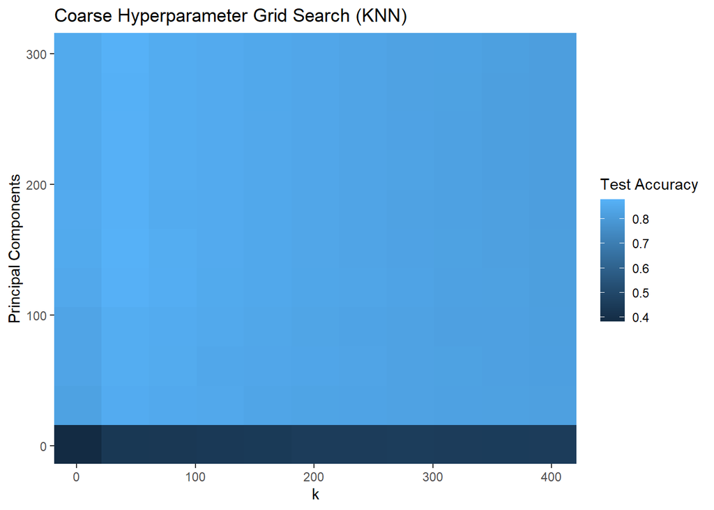

```r
knn_test_acc <- function(k, pcs) {
  test_preds <- knn(train=X_train.pcs[1:pcs], test=X_test.pcs[1:pcs],
                    cl=y_train$index, k = k)
  return (length(which(y_test$index == test_preds)) / test_len)
}

min_pcs <- 1
max_pcs <- 301
pc_interval = 30

min_k <- 1
max_k <- 401
k_interval = 40

coarse_knn_grid <- expand.grid(pcs=seq(min_pcs, max_pcs, pc_interval),
                               k=seq(min_k, max_k, k_interval))

for (row in rownames(coarse_knn_grid)) {
  pcs <- coarse_knn_grid[row,]$pcs
  k <- coarse_knn_grid[row,]$k
  coarse_knn_grid[row, "test_acc"] <- knn_test_acc(k, pcs)
}

coarse_knn <- ggplot(coarse_knn_grid, aes(x = k, y = pcs, fill = test_acc)) +
  geom_tile()  +
  labs(title="Coarse Hyperparameter Grid Search (KNN)", x="k",
       y="Principal Components", fill="Test Accuracy") +
  coord_cartesian(xlim = c(min_k, tail(coarse_knn_grid, 1)$k),
                  ylim = c(min_pcs, tail(coarse_knn_grid, 1)$pcs))

coarse_knn %>% plot
```

```r
coarse_knn_grid[which.max(coarse_knn_grid$test_acc),] %>% print
```

```
##    pcs  k  test_acc
## 17 151 41 0.8785205
```

$k$ and the number of principal components seem to be independent in determining the test accuracy of the model. Thus, we can save time by simply tuning $k$ at some relatively low number of principal components.

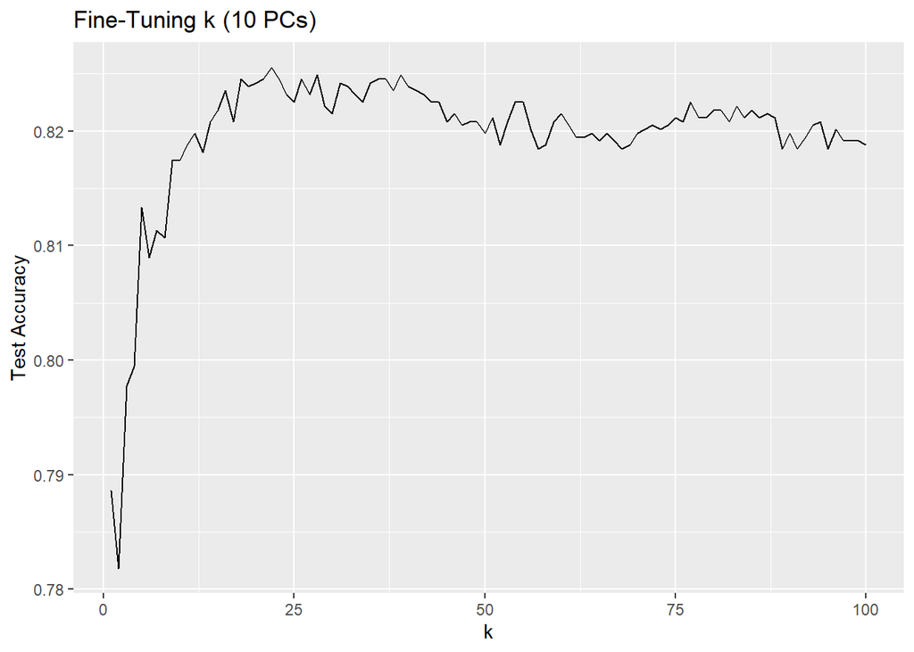

```r
fine_k <- 1:100

fine_k_acc <- sapply(fine_k, knn_test_acc, pcs=10)

fine_k_knn <- ggplot() +
  geom_line(aes(x=fine_k, fine_k_acc)) +
  labs(title="Fine-Tuning k (10 PCs)", x="k",
       y="Test Accuracy")

fine_k_knn %>% plot
```

```r
which.max(fine_k_acc) %>% print
```

```
## [1] 22
```

```r
fine_k_acc[which.max(fine_k_acc)] %>% print
```

```
## [1] 0.8255853
```

Plot the test accuracy at different numbers of principal components for $k=20$.

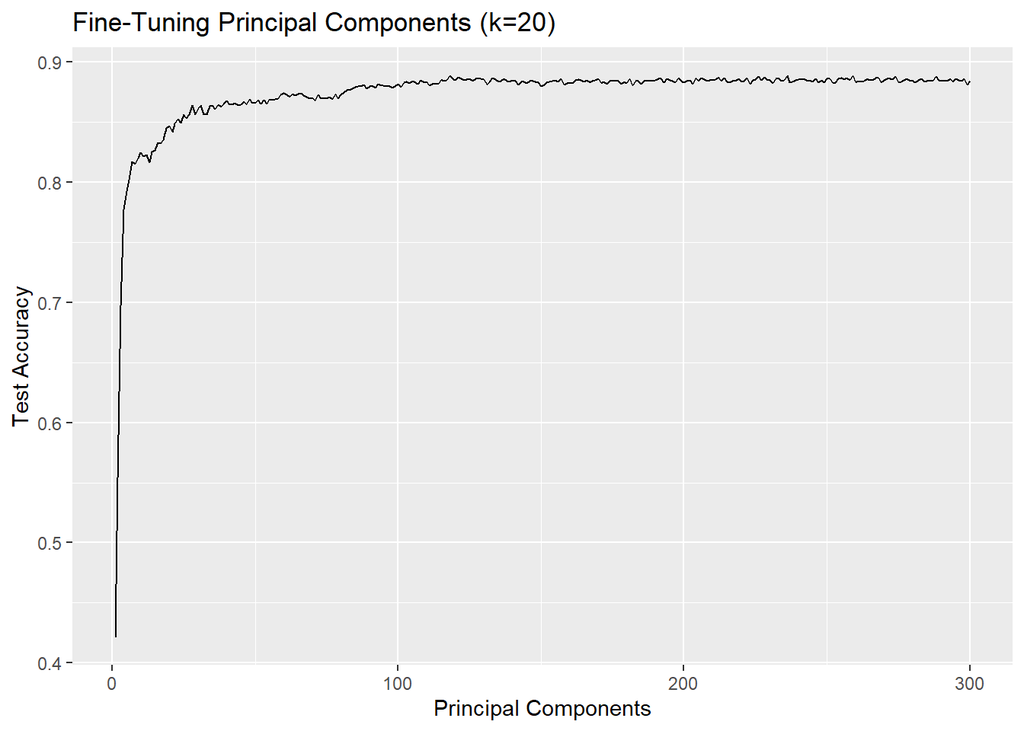

```r
fine_pcs <- 1:300

fine_pcs_acc <- sapply(fine_pcs, knn_test_acc, k=20)

fine_pcs_knn <- ggplot() +
  geom_line(aes(x=fine_pcs, fine_pcs_acc)) +
  labs(title="Fine-Tuning Principal Components (k=20)", x="Principal Components",
       y="Test Accuracy")

fine_pcs_knn %>% plot
```

```r
which.max(fine_pcs_acc) %>% print
```

```
## [1] 118
```

```r
fine_pcs_acc[which.max(fine_pcs_acc)] %>% print
```

```
## [1] 0.8887004
```

How does this compare to performing KNN on the original dataset?

```r
full_knn.start <- Sys.time()
full_knn_preds <- knn(train=X_train, test=X_test,
                   cl=y_train$index, k = 20)
full_knn.end <- Sys.time()
length(which(y_test$index == full_knn_preds)) / test_len %>% print
```

```
## [1] 2947
```

```
## [1] 0.8832711
```

```r
(full_knn.end - full_knn.start) %>% print
```

```
## Time difference of 44.84508 secs
```

```r
pca_knn.start <- Sys.time()
pca_knn_preds <- knn(train=X_train.pcs[1:120], test=X_test.pcs[1:120],
                   cl=y_train$activity, k = 20)
pca_knn.end <- Sys.time()
(pca_knn.end - pca_knn.start) %>% print
```

```
## Time difference of 8.221683 secs
```

Create a confusion matrix and generate descriptive statistics.

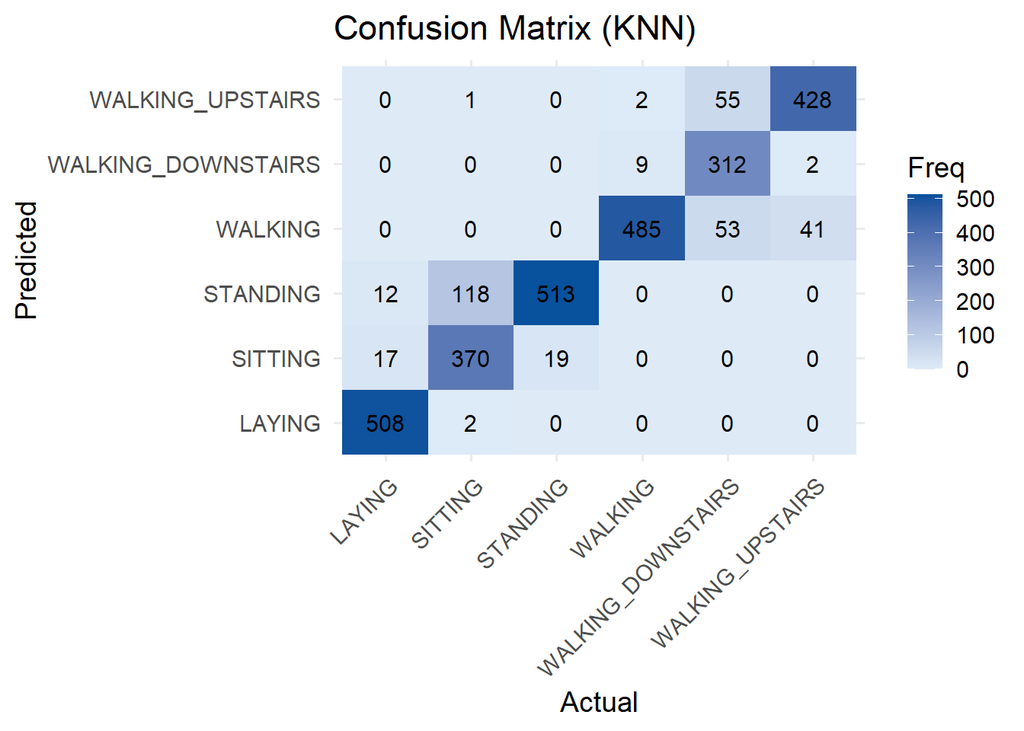

```r
knn_cm <- confusionMatrix(pca_knn_preds, as.factor(y_test$activity))

knn_cm_df <- as.data.frame(knn_cm$table)
colnames(knn_cm_df) <- c("Predicted", "Actual", "Freq")

knn_cm_plot <- ggplot(knn_cm_df, aes(x = Actual, y = Predicted, fill = Freq)) +
  geom_tile() +
  geom_text(aes(label = Freq), color = "black", size = 4) +
  scale_fill_gradient(low = "#deebf7", high = "#08519c") +
  theme_minimal(base_size = 14) +
  labs(
    title = "Confusion Matrix (KNN)",
    x = "Actual",
    y = "Predicted"
  ) +
  theme(axis.text.x = element_text(angle = 45, hjust = 1))

knn_cm_plot %>% plot
```

```r
knn_cm$overall[c("Accuracy")] %>% print
```

```
##  Accuracy
## 0.8876824
```

```r
knn_metrics <- knn_cm$byClass[, c("Precision",
                                  "Recall", "F1")]
knn_metrics %>% print
```

```
##                           Precision    Recall        F1
## Class: LAYING             0.9960784 0.9459963 0.9703916
## Class: SITTING            0.9113300 0.7535642 0.8249721
## Class: STANDING           0.7978227 0.9642857 0.8731915
## Class: WALKING            0.8376511 0.9778226 0.9023256
## Class: WALKING_DOWNSTAIRS 0.9659443 0.7428571 0.8398385
## Class: WALKING_UPSTAIRS   0.8806584 0.9087049 0.8944619
```